# F4SC. Optimization of TES parameters

- Show All Code
- Hide All Code
- View Source

Author

Bertrand Haas

Published

October 30, 2025

# R environment setting

Required libraries:

```r
cran_repo <- "https://ftp.fau.de/cran"
list_Rpack2use <-
  c("rmarkdown",
    "conflicted",
    "devtools",
    "knitr",
    "quarto",
    "bookdown",
    #shiny,
    "DT",
    "Hmisc",
    "tidyverse",
    "magrittr",
    "lubridate",
    "hms",
    "glue",
    "skimr",
    "lobstr",
    "janitor",
    "zeallot",
    "stringi",
    "lemon",
    "crayon",
    "jsonlite",
    #"officer",
    "TSA",
    "tsibble",
    "fable",
    "feasts",
    "imputeTS",
    "readxl",
    "slider",
    "reticulate",
    "aws.s3",
    "paws",
    "RAthena",
    "botor",
    "RPostgres",
    "DBI",
    "RJDBC",
    "dbplyr",
    "arrow",
    "geosphere",
    "viridis")

list_installed_packages <- names(installed.packages()[,2])
for (Rpack in list_Rpack2use) {
  if (! Rpack %in% list_installed_packages) {
    print(paste("Installing", Rpack))
    install.packages(Rpack, repos = cran_repo, )
  } else {
    print(paste(Rpack, "already installed."))
  }
}
```

Loaded librairies:

```r
list_Rpack2load_not <-
  c("conflicted",
    "devtools",
    "paws",
    "RAthena",
    "botor",
    "arrow",
    "RPostgres",
    "DBI",
    "RJDBC",
    "dbplyr",
    "aws.s3",
    "arrow",
    "reticulate",
    "slider",
    "stringi",
    "geosphere",
    "blah")
list_Rpack2load <- setdiff(list_Rpack2use, list_Rpack2load_not)
list_Rpack2load
```

```
 [1] "rmarkdown" "knitr"     "quarto"    "bookdown"  "DT"        "Hmisc"
 [7] "tidyverse" "magrittr"  "lubridate" "hms"       "glue"      "skimr"
[13] "lobstr"    "janitor"   "zeallot"   "lemon"     "crayon"    "jsonlite"
[19] "TSA"       "tsibble"   "fable"     "feasts"    "imputeTS"  "readxl"
[25] "viridis"
```

```r
for (Rpack in list_Rpack2load) {
  library(Rpack, character.only = TRUE)
}

conflicted::conflicts_prefer(pillar::dim_desc)
conflicted::conflicts_prefer(magrittr::extract)
conflicted::conflicts_prefer(dplyr::filter)
conflicted::conflicts_prefer(jsonlite::flatten)
conflicted::conflicts_prefer(hms::hms)
conflicted::conflicts_prefer(dbplyr::ident)
conflicted::conflicts_prefer(lubridate::interval)
conflicted::conflicts_prefer(dplyr::lag)
conflicted::conflicts_prefer(readxl::read_xlsx)
conflicted::conflicts_prefer(magrittr::set_names)
conflicted::conflicts_prefer(dbplyr::sql)
conflicted::conflicts_prefer(Hmisc::src)
conflicted::conflicts_prefer(dplyr::summarize)
conflicted::conflicts_prefer(magrittr::is_in)
```

```r
#To pass if interactive
#rendering <- TRUE
#time_all <- proc.time()

source("./scripts_gal/misc_funs.R")

dir_data <- "./data"

if (!dir.exists(dir_data)) {
  dir.create(dir_data)
}
```

# Optimization by grid search

We first load our usual synthetic data:

```r
fpath_ts3 <- glue("{dir_data}/synthetic_TS_03.tsv")
df_ts3 <-
  read_tsv(fpath_ts3)
df_ts3
```

```
# A tibble: 1,009 × 5
    year day        day_noy  dd_t   d_t
   <dbl> <date>     <chr>   <dbl> <dbl>
 1  2023 2023-01-01 0-01-01  2.80  2.68
 2  2023 2023-01-02 0-01-02  2.86  1.72
 3  2023 2023-01-03 0-01-03  2.92  3.75
 4  2023 2023-01-04 0-01-04  2.98  3.79
 5  2023 2023-01-05 0-01-05  3.03  4.82
 6  2023 2023-01-06 0-01-06  3.08  1.85
 7  2023 2023-01-07 0-01-07  3.13  2.88
 8  2023 2023-01-08 0-01-08  3.17  2.90
 9  2023 2023-01-09 0-01-09  3.22  2.93
10  2023 2023-01-10 0-01-10  3.25  1.95
# ℹ 999 more rows
```

```r
n_dat <- nrow(df_ts3)
```

## DES grid search (HWK from DES session)

We first need to code functions for DES smoothing:

### Additive DES

Let’s recall the recurrence formulae for $a(t)$ and $b(t)$ with dampening factor $phi$:
$$\begin{align*}
a(t) &= \alpha d(t) + (1 - \alpha) (a(t-1) + \phi b(t-1)) \\
b(t) &= \beta (a(t) - a(t-1)) + (1 - \beta) \phi b(t-1)
\end{align*}$$
Once we have computed all the $a(t)$ and $b(t)$, we can compute the forecasts for horizon $k$:
$$f(t+1) = a(t) + (\phi + \phi^2 + \dots + \phi^k) * b(t)$$

```r
fun_des_add <- function(df_0, a_0, b_0, alf_0, bet_0, fi_0 = 1, hoz_0 = 1) {
  df_0$a_t = a_0
  df_0$b_t = b_0
  for (t in 2:nrow(df_0)) {
    df_0$a_t[t] = alf_0 * df_0$d_t[t] + (1 - alf_0) * (df_0$a_t[t-1] + fi_0 * df_0$b_t[t-1])
    df_0$b_t[t] = bet_0 * (df_0$a_t[t] - df_0$a_t[t-1]) + (1 - bet_0) * fi_0 * df_0$b_t[t-1]
  }
  sum_fi = 0
  for (i in 1:hoz_0) {
    sum_fi = sum_fi + fi_0^i
  }
  df_0 %<>%
    mutate(fcast_des = lag(a_t) + sum_fi * lag(b_t))
  return(df_0)
}

print(fun_des_add)
```

```
function (df_0, a_0, b_0, alf_0, bet_0, fi_0 = 1, hoz_0 = 1)
{
    df_0$a_t = a_0
    df_0$b_t = b_0
    for (t in 2:nrow(df_0)) {
        df_0$a_t[t] = alf_0 * df_0$d_t[t] + (1 - alf_0) * (df_0$a_t[t -
            1] + fi_0 * df_0$b_t[t - 1])
        df_0$b_t[t] = bet_0 * (df_0$a_t[t] - df_0$a_t[t - 1]) +
            (1 - bet_0) * fi_0 * df_0$b_t[t - 1]
    }
    sum_fi = 0
    for (i in 1:hoz_0) {
        sum_fi = sum_fi + fi_0^i
    }
    df_0 %<>% mutate(fcast_des = lag(a_t) + sum_fi * lag(b_t))
    return(df_0)
}
```

### Multiplicative DES

```r
fun_des_mult <- function(df_0, a_0, b_0, alf_0, bet_0, fi_0 = 1, hoz_0 = 1) {
  df_0$a_t = a_0
  df_0$b_t = b_0
  for (t in 2:nrow(df_0)) {
    df_0$a_t[t] = alf_0 * df_0$d_t[t] + (1 - alf_0) * (df_0$a_t[t-1] * df_0$b_t[t-1]^fi_0)
    df_0$b_t[t] = bet_0 * (df_0$a_t[t] / df_0$a_t[t-1]) + (1 - bet_0) * df_0$b_t[t-1]^fi_0
  }
  sum_fi = 0
  for (i in 1:hoz_0) {
    sum_fi = sum_fi + fi_0^i
  }
  df_0 %<>%
    mutate(fcast_des = lag(a_t) * lag(b_t)^sum_fi)
  return(df_0)
}

print(fun_des_mult)
```

```
function (df_0, a_0, b_0, alf_0, bet_0, fi_0 = 1, hoz_0 = 1)
{
    df_0$a_t = a_0
    df_0$b_t = b_0
    for (t in 2:nrow(df_0)) {
        df_0$a_t[t] = alf_0 * df_0$d_t[t] + (1 - alf_0) * (df_0$a_t[t -
            1] * df_0$b_t[t - 1]^fi_0)
        df_0$b_t[t] = bet_0 * (df_0$a_t[t]/df_0$a_t[t - 1]) +
            (1 - bet_0) * df_0$b_t[t - 1]^fi_0
    }
    sum_fi = 0
    for (i in 1:hoz_0) {
        sum_fi = sum_fi + fi_0^i
    }
    df_0 %<>% mutate(fcast_des = lag(a_t) * lag(b_t)^sum_fi)
    return(df_0)
}
```

### KPI gathering

Here we use the usual MAE, MAPE, MedAPE, and WAPE as KPIs, but we also introduce a new one that is comparatively not used very much, but worth knowing for its nice properties, the MASE (Mean Absolute Scaled Error.

#### The base MASE

It was introduced among others by Rob Hyndman and is explained in his book [Forecasting: Principles and Practice](https://otexts.com/fpp2/accuracy.html#scaled-errors).

It is similar to the WAPE, which is the ratio of MAE over the mean of the actuals. But the MASE is the ratio of the MAE for the forecast method of interest, to the MAE for naive forecasting. Or, in terms of errors, with $e(t) = f(t) - d(t)$ using the current notations (and starting at $t = 0$), we define the scaled error:
$$q(t) = \frac{e(t)}{\frac{1}{n} \sum_{t=1}^T|d(t) - d(t-1)|}$$
Then the MASE is
$$MASE = mean(|q(t)|)$$

It is worth noting that naive forecasting is the best forecasting method (in terms of the usual KPIs) for Random Walk processes. A discrete random walk process is defined as:
$$y(t) = y(t-1) + \epsilon$$
where $\epsilon \sim N(0, \sigma^2)$. This is why naive forecasting is written **rwf** in the R “forecast” package.

#### Seasonal MASE

There is a seasonal version of the MASE, let’s write it seaMASE, that is particularly fit in SC when we have significant seasonal effects. Here we use the seasonal naive forecast, that is, instead of going back one day, we go back a full seasonal period.
$$q(t) = \frac{e(t)}{\frac{1}{n} \sum_{t=1}^T|d(t) - d(t-p)|}$$
Then the seaMASE is again the mean of the absolute values of the $q(t)$’s.

FYI, there are other variants of the MASE, for example taking into account “drift” in random walks, which is equivalent to a linear trend.

We can now code the MASE function (with default season 1):

```r
fun_mase <- function(f_t, d_t, p = 1) {
  e_t <- f_t - d_t
  scal <- mean(abs(d_t - lag(d_t, n = p)), na.rm = TRUE)
  return(mean(abs(e_t[(p+1):length(e_t)]), na.rm = TRUE)/scal)
}

print(fun_mase)
```

```
function (f_t, d_t, p = 1)
{
    e_t <- f_t - d_t
    scal <- mean(abs(d_t - lag(d_t, n = p)), na.rm = TRUE)
    return(mean(abs(e_t[(p + 1):length(e_t)]), na.rm = TRUE)/scal)
}
```

#### MAE, MAPE, WAPE, MedAPE, and WASE gathering

While we are at it, let’s also code our usual KPIs:

```r
fun_mae <- function(f_t, d_t) {
  return(mean(abs(f_t - d_t), na.rm = TRUE))
}

fun_mape <- function(f_t, d_t) {
  ape <- abs(f_t - d_t) / d_t * 100
  return(mean(ape, na.rm = TRUE))
}

fun_medape <- function(f_t, d_t) {
  ape <- abs(f_t - d_t) / d_t * 100
  return(median(ape, na.rm = TRUE))
}

fun_wape <- function(f_t, d_t) {
  return(fun_mae(f_t, d_t) / mean(d_t, na.rm = TRUE) * 100)
}
```

Next we define a function to gather the KPIs over a 11x11 default $(\alpha, \beta)$ grid with each parameter ranging from $0$ to $1$ by steps of $0.1$, and $phi$ by default set to $1$ (as a 1x1 grid). The horizon is also set to $1$ by default. This function also takes the forecast function as input (so far, it can be fun_des_add, or fun_des_mult).

```r
seq_11 <- seq(0, 1, by = 0.1) %>% round(digits = 1)

fun_kpi_des <- function(df_00, a_00, b_00,
                        fun_des,
                        seq_alf = seq_11,
                        seq_bet = seq_11,
                        seq_fi  = 1,
                        hoz_00  = 1) {
  #Computes KPIs for all (alpha, beta) parameters from the grid seq_alf X seq_bet
  # both for SES and DES
  df_param <- tibble()
  alf_i <- 0
  for (alf in seq_alf) {
    print(glue("alpha = {alf}"))
    alf_i <- alf_i + 1
    time_alf <- proc.time()
    for (bet in seq_bet) {
      for (fi in seq_fi) {
        df_1 <-
          fun_des(df_0  = df_00,
                  a_0   = a_00,  b_0   = b_00,
                  alf_0 = alf,   bet_0 = bet,
                  fi_0  = fi,    hoz_0 = hoz_00)
        df_param_i <-
          tibble(mae       = fun_mae( df_1$fcast_des, df_1$d_t),
                 mae_d     = fun_mae( df_1$dd_t,      df_1$d_t),
                 mape      = fun_mape(df_1$fcast_des, df_1$d_t),
                 mape_d    = fun_mape(df_1$dd_t,      df_1$d_t),
                 medape    = fun_mape(df_1$fcast_des, df_1$d_t),
                 medape_d  = fun_mape(df_1$dd_t,      df_1$d_t),
                 wape      = fun_wape(df_1$fcast_des, df_1$d_t),
                 wape_d    = fun_wape(df_1$dd_t,      df_1$d_t),
                 mase      = fun_mase(df_1$fcast_des, df_1$d_t),
                 mase_d    = fun_mase(df_1$dd_t,      df_1$d_t),
                 seamase   = fun_mase(df_1$fcast_des, df_1$d_t, p = 365),
                 seamase_d = fun_mase(df_1$dd_t,      df_1$d_t, p = 365)) %>%
          mutate(alpha   = alf,
                 beta    = bet,
                 phi     = fi,
                 horizon = hoz_00)
        df_param %<>% bind_rows(df_param_i)
      }
    }
    time_alf <- proc.time() - time_alf
    print(glue("Alpha iteration {alf_i}: {round(time_alf[3], digits = 2)} seconds"))
  }
  df_param %<>%
    relocate(c(alpha, beta, phi, horizon))
  return(df_param)
}

print(fun_kpi_des)
```

```
function (df_00, a_00, b_00, fun_des, seq_alf = seq_11, seq_bet = seq_11,
    seq_fi = 1, hoz_00 = 1)
{
    df_param <- tibble()
    alf_i <- 0
    for (alf in seq_alf) {
        print(glue("alpha = {alf}"))
        alf_i <- alf_i + 1
        time_alf <- proc.time()
        for (bet in seq_bet) {
            for (fi in seq_fi) {
                df_1 <- fun_des(df_0 = df_00, a_0 = a_00, b_0 = b_00,
                  alf_0 = alf, bet_0 = bet, fi_0 = fi, hoz_0 = hoz_00)
                df_param_i <- tibble(mae = fun_mae(df_1$fcast_des,
                  df_1$d_t), mae_d = fun_mae(df_1$dd_t, df_1$d_t),
                  mape = fun_mape(df_1$fcast_des, df_1$d_t),
                  mape_d = fun_mape(df_1$dd_t, df_1$d_t), medape = fun_mape(df_1$fcast_des,
                    df_1$d_t), medape_d = fun_mape(df_1$dd_t,
                    df_1$d_t), wape = fun_wape(df_1$fcast_des,
                    df_1$d_t), wape_d = fun_wape(df_1$dd_t, df_1$d_t),
                  mase = fun_mase(df_1$fcast_des, df_1$d_t),
                  mase_d = fun_mase(df_1$dd_t, df_1$d_t), seamase = fun_mase(df_1$fcast_des,
                    df_1$d_t, p = 365), seamase_d = fun_mase(df_1$dd_t,
                    df_1$d_t, p = 365)) %>% mutate(alpha = alf,
                  beta = bet, phi = fi, horizon = hoz_00)
                df_param %<>% bind_rows(df_param_i)
            }
        }
        time_alf <- proc.time() - time_alf
        print(glue("Alpha iteration {alf_i}: {round(time_alf[3], digits = 2)} seconds"))
    }
    df_param %<>% relocate(c(alpha, beta, phi, horizon))
    return(df_param)
}
```

### Grid search for the best params

```r
a_1 <- df_ts3$d_t[1]
b_1 <- df_ts3$d_t[2] - df_ts3$d_t[1]
```

Let’s start with initial value $a(0) = d(0) = 2.6793689$ for both SES and DES, and $b(0) = d(1) - d(0) = -0.962338$.

```r
df_param_ades_1 <- fun_kpi_des(df_ts3, a_1, b_1, fun_des_add)
```

```
alpha = 0
Alpha iteration 1: 0.95 seconds
alpha = 0.1
Alpha iteration 2: 0.86 seconds
alpha = 0.2
Alpha iteration 3: 0.89 seconds
alpha = 0.3
Alpha iteration 4: 0.89 seconds
alpha = 0.4
Alpha iteration 5: 0.86 seconds
alpha = 0.5
Alpha iteration 6: 1.03 seconds
alpha = 0.6
Alpha iteration 7: 0.83 seconds
alpha = 0.7
Alpha iteration 8: 0.86 seconds
alpha = 0.8
Alpha iteration 9: 0.81 seconds
alpha = 0.9
Alpha iteration 10: 0.79 seconds
alpha = 1
Alpha iteration 11: 0.82 seconds
```

```r
df_param_ades_1
```

```
# A tibble: 121 × 16
   alpha  beta   phi horizon   mae mae_d  mape mape_d medape medape_d  wape
   <dbl> <dbl> <dbl>   <dbl> <dbl> <dbl> <dbl>  <dbl>  <dbl>    <dbl> <dbl>
 1     0   0       1       1  489.  1.28 9989.   25.9  9989.     25.9 8516.
 2     0   0.1     1       1  489.  1.28 9989.   25.9  9989.     25.9 8516.
 3     0   0.2     1       1  489.  1.28 9989.   25.9  9989.     25.9 8516.
 4     0   0.3     1       1  489.  1.28 9989.   25.9  9989.     25.9 8516.
 5     0   0.4     1       1  489.  1.28 9989.   25.9  9989.     25.9 8516.
 6     0   0.5     1       1  489.  1.28 9989.   25.9  9989.     25.9 8516.
 7     0   0.6     1       1  489.  1.28 9989.   25.9  9989.     25.9 8516.
 8     0   0.7     1       1  489.  1.28 9989.   25.9  9989.     25.9 8516.
 9     0   0.8     1       1  489.  1.28 9989.   25.9  9989.     25.9 8516.
10     0   0.9     1       1  489.  1.28 9989.   25.9  9989.     25.9 8516.
# ℹ 111 more rows
# ℹ 5 more variables: wape_d <dbl>, mase <dbl>, mase_d <dbl>, seamase <dbl>,
#   seamase_d <dbl>
```

```r
df_param_mdes_1 <- fun_kpi_des(df_ts3, a_1, b_1, fun_des_mult)
```

```
alpha = 0
Alpha iteration 1: 0.83 seconds
alpha = 0.1
Alpha iteration 2: 0.84 seconds
alpha = 0.2
Alpha iteration 3: 0.84 seconds
alpha = 0.3
Alpha iteration 4: 0.8 seconds
alpha = 0.4
Alpha iteration 5: 0.84 seconds
alpha = 0.5
Alpha iteration 6: 0.82 seconds
alpha = 0.6
Alpha iteration 7: 0.82 seconds
alpha = 0.7
Alpha iteration 8: 0.83 seconds
alpha = 0.8
Alpha iteration 9: 0.83 seconds
alpha = 0.9
Alpha iteration 10: 0.84 seconds
alpha = 1
Alpha iteration 11: 0.88 seconds
```

```r
df_param_mdes_1
```

```
# A tibble: 121 × 16
   alpha  beta   phi horizon   mae mae_d  mape mape_d medape medape_d  wape
   <dbl> <dbl> <dbl>   <dbl> <dbl> <dbl> <dbl>  <dbl>  <dbl>    <dbl> <dbl>
 1     0   0       1       1  5.74  1.28  100.   25.9   100.     25.9  100.
 2     0   0.1     1       1  5.74  1.28  100.   25.9   100.     25.9  100.
 3     0   0.2     1       1  5.74  1.28  100.   25.9   100.     25.9  100.
 4     0   0.3     1       1  5.74  1.28  100.   25.9   100.     25.9  100.
 5     0   0.4     1       1  5.74  1.28  100.   25.9   100.     25.9  100.
 6     0   0.5     1       1  5.74  1.28  100.   25.9   100.     25.9  100.
 7     0   0.6     1       1  5.74  1.28  100.   25.9   100.     25.9  100.
 8     0   0.7     1       1  5.74  1.28  100.   25.9   100.     25.9  100.
 9     0   0.8     1       1  5.74  1.28  100.   25.9   100.     25.9  100.
10     0   0.9     1       1  5.74  1.28  100.   25.9   100.     25.9  100.
# ℹ 111 more rows
# ℹ 5 more variables: wape_d <dbl>, mase <dbl>, mase_d <dbl>, seamase <dbl>,
#   seamase_d <dbl>
```

Let’s check the minimum KPIs and compare additive vs multiplicative DES:

```r
df_param_ades_1 %>%
  filter(mae    == min(mae)    |
         mape   == min(mape)   |
         medape == min(medape) |
         wape   == min(wape)   |
         mase   == min(mase))
```

```
# A tibble: 1 × 16
  alpha  beta   phi horizon   mae mae_d  mape mape_d medape medape_d  wape
  <dbl> <dbl> <dbl>   <dbl> <dbl> <dbl> <dbl>  <dbl>  <dbl>    <dbl> <dbl>
1   0.2   0.1     1       1  1.44  1.28  28.7   25.9   28.7     25.9  25.2
# ℹ 5 more variables: wape_d <dbl>, mase <dbl>, mase_d <dbl>, seamase <dbl>,
#   seamase_d <dbl>
```

```r
df_param_mdes_1 %>%
  filter(mae    == min(mae)    |
         mape   == min(mape)   |
         medape == min(medape) |
         wape   == min(wape)   |
         mase   == min(mase))
```

```
# A tibble: 1 × 16
  alpha  beta   phi horizon   mae mae_d  mape mape_d medape medape_d  wape
  <dbl> <dbl> <dbl>   <dbl> <dbl> <dbl> <dbl>  <dbl>  <dbl>    <dbl> <dbl>
1   0.2   0.1     1       1  1.51  1.28  31.3   25.9   31.3     25.9  26.3
# ℹ 5 more variables: wape_d <dbl>, mase <dbl>, mase_d <dbl>, seamase <dbl>,
#   seamase_d <dbl>
```

```r
alf_a1 <- 0.2
bet_a1 <- 0.1
```

Observations:  
* Each method (additive and multiplicative) yield only one row of minimum KPIs.  
This means that all the KPIs agree on their minimum (this is not always the case). * Both method agree on the best pair $(\alpha, \beta) = (0.2, 0.1)$.  
* The additive model seems a better fit to the data (the KPIs are lower than for the multiplicative model).

### Visualization

One advantage of grid search is that we can see how the KPI changes with one parameter (or even 2 parameters if we can plot in 3-D). For example, lets check how the KPIs change with alpha (setting beta to it optimal value $bet_a1$). We see that $\alpha = 0$ is way off. So as to not distort the plot too much, we start at $\alpha = 0.1$ and use log-y coordinates.

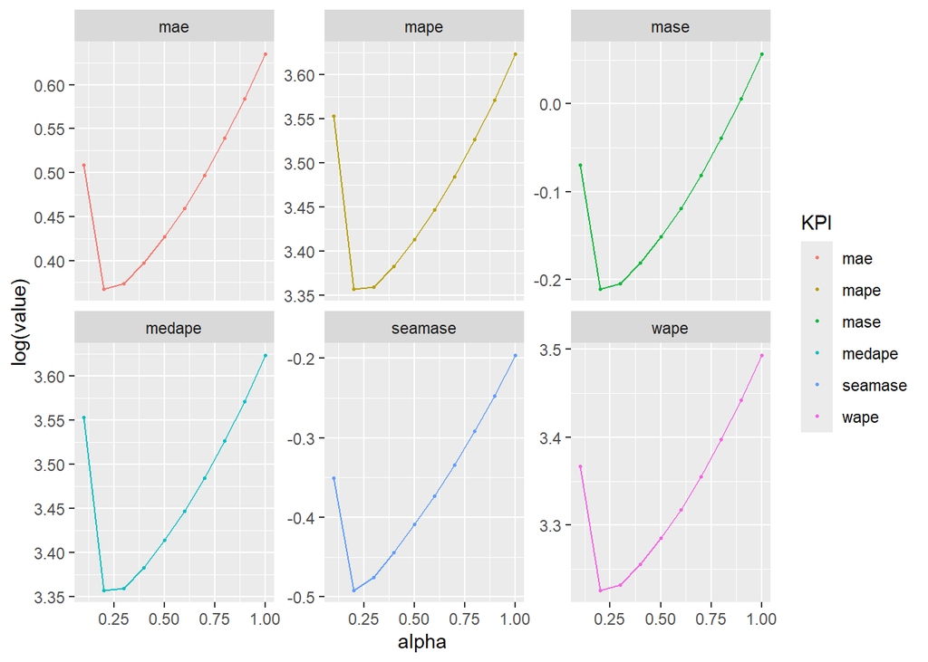

```r
df_param_ades_1 %>%
  filter(beta == bet_a1) %>%
  filter(alpha > 0) %>%
  select(alpha, mae, mape, medape, wape, mase, seamase) %>%
  pivot_longer(cols      = c(mae, mape, medape, wape, mase, seamase),
               names_to  = "KPI",
               values_to = "value") %>%
  ggplot(aes(x = alpha, y = log(value), color = KPI)) +
    geom_point(size = 0.5) +
    geom_line(show.legend = FALSE) +
    facet_wrap(~ KPI,
               scale = "free_y")
```

And similarly for $\beta$ with $\alpha$ set to its optimal value $\alf_a1$.

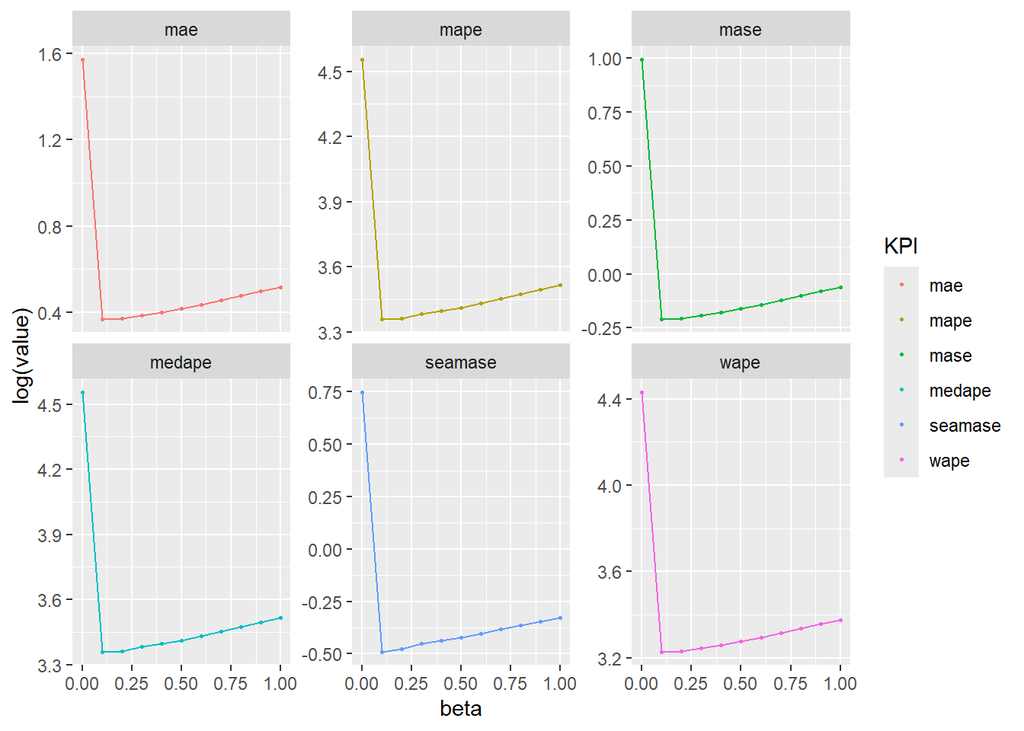

```r
df_param_ades_1 %>%
  filter(alpha == alf_a1) %>%
  #filter(beta > 0) %>%
  select(beta, mae, mape, medape, wape, mase, seamase) %>%
  pivot_longer(cols      = c(mae, mape, medape, wape, mase, seamase),
               names_to  = "KPI",
               values_to = "value") %>%
  ggplot(aes(x = beta, y = log(value), color = KPI)) +
    geom_point(size = 0.5) +
    geom_line(show.legend = FALSE) +
    facet_wrap(~ KPI,
               scale = "free_y")
```

### Analysis of $\phi$

Let’s re-run our grid search with phi ranging over $(0.5, 0.8, 1)$ and for horizon 7 days.

```r
df_param_addes_2 <- fun_kpi_des(df_ts3, a_1, b_1, fun_des_add, seq_fi = c(0.5, 0.8, 1), hoz_00 = 7)
```

```
alpha = 0
Alpha iteration 1: 2.76 seconds
alpha = 0.1
Alpha iteration 2: 2.56 seconds
alpha = 0.2
Alpha iteration 3: 2.68 seconds
alpha = 0.3
Alpha iteration 4: 2.45 seconds
alpha = 0.4
Alpha iteration 5: 2.64 seconds
alpha = 0.5
Alpha iteration 6: 2.64 seconds
alpha = 0.6
Alpha iteration 7: 2.64 seconds
alpha = 0.7
Alpha iteration 8: 3.33 seconds
alpha = 0.8
Alpha iteration 9: 3.76 seconds
alpha = 0.9
Alpha iteration 10: 3.5 seconds
alpha = 1
Alpha iteration 11: 3.03 seconds
```

```r
df_param_addes_2
```

```
# A tibble: 363 × 16
   alpha  beta   phi horizon    mae mae_d    mape mape_d  medape medape_d   wape
   <dbl> <dbl> <dbl>   <dbl>  <dbl> <dbl>   <dbl>  <dbl>   <dbl>    <dbl>  <dbl>
 1     0   0     0.5       7   4.03  1.28    62.7   25.9    62.7     25.9   70.2
 2     0   0     0.8       7   6.91  1.28   126.    25.9   126.      25.9  120.
 3     0   0     1         7 494.    1.28 10116.    25.9 10116.      25.9 8616.
 4     0   0.1   0.5       7   4.03  1.28    62.7   25.9    62.7     25.9   70.2
 5     0   0.1   0.8       7   6.91  1.28   126.    25.9   126.      25.9  120.
 6     0   0.1   1         7 494.    1.28 10116.    25.9 10116.      25.9 8616.
 7     0   0.2   0.5       7   4.03  1.28    62.7   25.9    62.7     25.9   70.2
 8     0   0.2   0.8       7   6.91  1.28   126.    25.9   126.      25.9  120.
 9     0   0.2   1         7 494.    1.28 10116.    25.9 10116.      25.9 8616.
10     0   0.3   0.5       7   4.03  1.28    62.7   25.9    62.7     25.9   70.2
# ℹ 353 more rows
# ℹ 5 more variables: wape_d <dbl>, mase <dbl>, mase_d <dbl>, seamase <dbl>,
#   seamase_d <dbl>
```

Let’s check the minimum KPIs:

```r
df_param_addes_2 %>%
  filter(mae     == min(mae)    |
         mape    == min(mape)   |
         medape  == min(medape) |
         wape    == min(wape)   |
         mase    == min(mase)   |
         seamase == min(seamase))
```

```
# A tibble: 2 × 16
  alpha  beta   phi horizon   mae mae_d  mape mape_d medape medape_d  wape
  <dbl> <dbl> <dbl>   <dbl> <dbl> <dbl> <dbl>  <dbl>  <dbl>    <dbl> <dbl>
1   0.1   0.3   0.8       7  1.41  1.28  28.4   25.9   28.4     25.9  24.6
2   0.1   0.4   0.8       7  1.41  1.28  28.4   25.9   28.4     25.9  24.6
# ℹ 5 more variables: wape_d <dbl>, mase <dbl>, mase_d <dbl>, seamase <dbl>,
#   seamase_d <dbl>
```

```r
alf_a2 <- 0.1
bet_a2 <- 0.4
```

Here we see a small discrepancy between MASE and seaMASE in terms of which parameters are optimal. Let’s pick $\alpha = 0.1$ and $\beta = 0.4$ and check the KPIs for the different values of phi:

```r
df_param_addes_2 %>%
  filter(alpha == alf_a2,
         beta  == bet_a2) %>%
  select(-matches("_d$"))
```

```
# A tibble: 3 × 10
  alpha  beta   phi horizon   mae  mape medape  wape  mase seamase
  <dbl> <dbl> <dbl>   <dbl> <dbl> <dbl>  <dbl> <dbl> <dbl>   <dbl>
1   0.1   0.4   0.5       7  1.47  30.1   30.1  25.7 0.826   0.643
2   0.1   0.4   0.8       7  1.41  28.4   28.4  24.6 0.792   0.604
3   0.1   0.4   1         7  2.03  42.2   42.2  35.4 1.14    0.883
```

We see a significant drop specially between $\phi = 1$ and $\phi = 0.8$.

### Is SES included in DES?

We might think that setting $\beta$ to zero in the DES model might yield the SES model, but from the recurrence equations we see that in that case $b(t) = b(0)$ for all $t$, and therefore $a(t) = \alpha d(t) + (1-\alpha) a(t) + (1-\alpha) b(0)$, so it has a constant bias of $(1 - \alpha) b(0)$. The only way to include SES in DES is to set both $\beta = 0$ AND $b(0) = 0$.

Let’s compute our KPIs on our $(\alpha, \beta)$ grid, setting $b(0) = 0$, then filtering to $\beta = 0$.

```r
df_param_ses_1 <- fun_kpi_des(df_ts3, a_1, 0, fun_des_add)
```

```
alpha = 0
Alpha iteration 1: 1.11 seconds
alpha = 0.1
Alpha iteration 2: 1.39 seconds
alpha = 0.2
Alpha iteration 3: 0.97 seconds
alpha = 0.3
Alpha iteration 4: 0.86 seconds
alpha = 0.4
Alpha iteration 5: 1.28 seconds
alpha = 0.5
Alpha iteration 6: 2.41 seconds
alpha = 0.6
Alpha iteration 7: 1.22 seconds
alpha = 0.7
Alpha iteration 8: 1.22 seconds
alpha = 0.8
Alpha iteration 9: 1.12 seconds
alpha = 0.9
Alpha iteration 10: 1 seconds
alpha = 1
Alpha iteration 11: 1.06 seconds
```

```r
df_param_ses_1 %<>%
  filter(beta == 0) %>%
  select(-c(beta, phi))
df_param_ses_1
```

```
# A tibble: 11 × 14
   alpha horizon   mae mae_d  mape mape_d medape medape_d  wape wape_d  mase
   <dbl>   <dbl> <dbl> <dbl> <dbl>  <dbl>  <dbl>    <dbl> <dbl>  <dbl> <dbl>
 1   0         1  3.15  1.28  46.3   25.9   46.3     25.9  55.0   22.2 1.77
 2   0.1       1  1.56  1.28  32.4   25.9   32.4     25.9  27.2   22.2 0.876
 3   0.2       1  1.43  1.28  29.0   25.9   29.0     25.9  24.9   22.2 0.801
 4   0.3       1  1.42  1.28  28.7   25.9   28.7     25.9  24.8   22.2 0.797
 5   0.4       1  1.44  1.28  29.2   25.9   29.2     25.9  25.2   22.2 0.810
 6   0.5       1  1.48  1.28  29.9   25.9   29.9     25.9  25.8   22.2 0.831
 7   0.6       1  1.53  1.28  30.7   25.9   30.7     25.9  26.6   22.2 0.856
 8   0.7       1  1.58  1.28  31.7   25.9   31.7     25.9  27.5   22.2 0.885
 9   0.8       1  1.64  1.28  32.8   25.9   32.8     25.9  28.6   22.2 0.920
10   0.9       1  1.71  1.28  34.1   25.9   34.1     25.9  29.8   22.2 0.958
11   1         1  1.78  1.28  35.5   25.9   35.5     25.9  31.1   22.2 1
# ℹ 3 more variables: mase_d <dbl>, seamase <dbl>, seamase_d <dbl>
```

Then we check the parameters for the minimum KPIs and compare with those of DES:

```r
print("SES best param:")
```

```
[1] "SES best param:"
```

```r
df_param_ses_1 %>%
  filter(mae     == min(mae)    |
         mape    == min(mape)   |
         medape  == min(medape) |
         wape    == min(wape)   |
         mase    == min(mase)   |
         seamase == min(seamase))
```

```
# A tibble: 1 × 14
  alpha horizon   mae mae_d  mape mape_d medape medape_d  wape wape_d  mase
  <dbl>   <dbl> <dbl> <dbl> <dbl>  <dbl>  <dbl>    <dbl> <dbl>  <dbl> <dbl>
1   0.3       1  1.42  1.28  28.7   25.9   28.7     25.9  24.8   22.2 0.797
# ℹ 3 more variables: mase_d <dbl>, seamase <dbl>, seamase_d <dbl>
```

```r
print("DES best params:")
```

```
[1] "DES best params:"
```

```r
df_param_ades_1 %>%
  filter(mae     == min(mae)    |
         mape    == min(mape)   |
         medape  == min(medape) |
         wape    == min(wape)   |
         mase    == min(mase)   |
         seamase == min(seamase))
```

```
# A tibble: 1 × 16
  alpha  beta   phi horizon   mae mae_d  mape mape_d medape medape_d  wape
  <dbl> <dbl> <dbl>   <dbl> <dbl> <dbl> <dbl>  <dbl>  <dbl>    <dbl> <dbl>
1   0.2   0.1     1       1  1.44  1.28  28.7   25.9   28.7     25.9  25.2
# ℹ 5 more variables: wape_d <dbl>, mase <dbl>, mase_d <dbl>, seamase <dbl>,
#   seamase_d <dbl>
```

We see something that might appear surprising here. The KPIs for SES are better (lower) that those for DES. How can a more sophisticated model incorporating a simpler model can do worse that the simpler one?

This is because this version of DES does not quite incorporate the same version of SES. We started with parameter $b(0) = b_1$ in DES and with $b(0) = 0$ in SES. To compare apples to apples, we need to re-compute our array of KPIs for DES starting with $b(0) = 0$ as well.

```r
df_param_ades_3 <- fun_kpi_des(df_ts3, a_1, 0, fun_des_add)
```

```
alpha = 0
Alpha iteration 1: 1.1 seconds
alpha = 0.1
Alpha iteration 2: 1.15 seconds
alpha = 0.2
Alpha iteration 3: 0.91 seconds
alpha = 0.3
Alpha iteration 4: 0.91 seconds
alpha = 0.4
Alpha iteration 5: 0.9 seconds
alpha = 0.5
Alpha iteration 6: 0.88 seconds
alpha = 0.6
Alpha iteration 7: 0.86 seconds
alpha = 0.7
Alpha iteration 8: 1.01 seconds
alpha = 0.8
Alpha iteration 9: 1.08 seconds
alpha = 0.9
Alpha iteration 10: 0.84 seconds
alpha = 1
Alpha iteration 11: 0.93 seconds
```

```r
df_param_ades_3
```

```
# A tibble: 121 × 16
   alpha  beta   phi horizon   mae mae_d  mape mape_d medape medape_d  wape
   <dbl> <dbl> <dbl>   <dbl> <dbl> <dbl> <dbl>  <dbl>  <dbl>    <dbl> <dbl>
 1     0   0       1       1  3.15  1.28  46.3   25.9   46.3     25.9  55.0
 2     0   0.1     1       1  3.15  1.28  46.3   25.9   46.3     25.9  55.0
 3     0   0.2     1       1  3.15  1.28  46.3   25.9   46.3     25.9  55.0
 4     0   0.3     1       1  3.15  1.28  46.3   25.9   46.3     25.9  55.0
 5     0   0.4     1       1  3.15  1.28  46.3   25.9   46.3     25.9  55.0
 6     0   0.5     1       1  3.15  1.28  46.3   25.9   46.3     25.9  55.0
 7     0   0.6     1       1  3.15  1.28  46.3   25.9   46.3     25.9  55.0
 8     0   0.7     1       1  3.15  1.28  46.3   25.9   46.3     25.9  55.0
 9     0   0.8     1       1  3.15  1.28  46.3   25.9   46.3     25.9  55.0
10     0   0.9     1       1  3.15  1.28  46.3   25.9   46.3     25.9  55.0
# ℹ 111 more rows
# ℹ 5 more variables: wape_d <dbl>, mase <dbl>, mase_d <dbl>, seamase <dbl>,
#   seamase_d <dbl>
```

Now we can compare again SES with DES on the same footing:

```r
print("SES best param:")
```

```
[1] "SES best param:"
```

```r
df_param_ses_1 %>%
  filter(mae     == min(mae)    |
         mape    == min(mape)   |
         medape  == min(medape) |
         wape    == min(wape)   |
         mase    == min(mase)   |
         seamase == min(seamase))
```

```
# A tibble: 1 × 14
  alpha horizon   mae mae_d  mape mape_d medape medape_d  wape wape_d  mase
  <dbl>   <dbl> <dbl> <dbl> <dbl>  <dbl>  <dbl>    <dbl> <dbl>  <dbl> <dbl>
1   0.3       1  1.42  1.28  28.7   25.9   28.7     25.9  24.8   22.2 0.797
# ℹ 3 more variables: mase_d <dbl>, seamase <dbl>, seamase_d <dbl>
```

```r
print("DES best params:")
```

```
[1] "DES best params:"
```

```r
df_param_ades_3 %>%
  filter(mae     == min(mae)    |
         mape    == min(mape)   |
         medape  == min(medape) |
         wape    == min(wape)   |
         mase    == min(mase)   |
         seamase == min(seamase))
```

```
# A tibble: 1 × 16
  alpha  beta   phi horizon   mae mae_d  mape mape_d medape medape_d  wape
  <dbl> <dbl> <dbl>   <dbl> <dbl> <dbl> <dbl>  <dbl>  <dbl>    <dbl> <dbl>
1   0.2   0.1     1       1  1.41  1.28  27.7   25.9   27.7     25.9  24.6
# ℹ 5 more variables: wape_d <dbl>, mase <dbl>, mase_d <dbl>, seamase <dbl>,
#   seamase_d <dbl>
```

We see now that using the DES model yileds better, not worse, KPIs.

## TES Grid search

We can now do the same thing with TES. It’s just more complicated…

```r
fun_tes_add <- function(df_0, a_0, b_0, s_0, alf_0, bet_0, gam_0, fi_0 = 1, hoz_0 = 1) {
  p_0 <- length(s_0)
  df_0 %<>%
    mutate(a_t = a_0,
           b_t = b_0,
           s_t = -1)
  df_0$s_t[1:p_0] <- s_0
  for (i in (p_0+1):nrow(df_0)) {
    df_0$a_t[i] <- alf_0 * (df_0$d_t[i] - df_0$s_t[i-p_0]) + (1-alf_0) * (df_0$a_t[i-1] + fi_0 * df_0$b_t[i-1])
    df_0$b_t[i] <- bet_0 * (df_0$a_t[i] - df_0$a_t[i-1]) + (1-bet_0) * fi_0 *df_0$b_t[i-1]
    df_0$s_t[i] <- gam_0 * (df_0$d_t[i] - df_0$a_t[i]) + (1-gam_0) * df_0$s_t[i-p_0]
  }
  sum_fi = 0
  for (i in 1:hoz_0) {
    sum_fi = sum_fi + fi_0^i
  }
  df_0 %<>%
    mutate(fcast_tes = lag(a_t) + sum_fi * lag(b_t) + lag(s_t, n = p_0 - hoz_0))
  return(df_0)
}

fun_tes_mult <- function(df_0, a_0, b_0, s_0, alf_0, bet_0, gam_0, fi_0 = 1, hoz_0 = 1) {
  p_0 <- length(s_0)
  df_0 %<>%
    mutate(a_t = a_0,
           b_t = b_0,
           s_t = -1)
  df_0$s_t[1:p_0] <- s_0
  for (i in (p_0+1):nrow(df_0)) {
    df_0$a_t[i] <- alf_0 * (df_0$d_t[i] / df_0$s_t[i-p_0]) + (1-alf_0) * (df_0$a_t[i-1] + fi_0 * df_0$b_t[i-1])
    df_0$b_t[i] <- bet_0 * (df_0$a_t[i] - df_0$a_t[i-1]) + (1-bet_0) * fi_0 * df_0$b_t[i-1]
    df_0$s_t[i] <- gam_0 * (df_0$d_t[i] / df_0$a_t[i]) + (1-gam_0) * df_0$s_t[i-p_0]
  }
  sum_fi = 0
  for (i in 1:hoz_0) {
    sum_fi = sum_fi + fi_0^i
  }
  df_0 %<>%
    mutate(fcast_tes = (lag(a_t) + sum_fi * lag(b_t)) * lag(s_t, n = p_0 - hoz_0))
  return(df_0)
}

fun_kpi_tes <- function(df_00, fun_tes, a_00, b_00, s_00,
                        p_00     = 365,
                        seq_alf = seq_11,
                        seq_bet = seq_11,
                        seq_gam = seq_11,
                        seq_fi  = 1,
                        hoz_00  = 1) {
  time_kpi_tes <- proc.time()
  df_param <- tibble()
  alf_i <- 0
  for (alf in seq_alf) {
    print(glue("alpha = {alf}"))
    alf_i <- alf_i + 1
    time_alf <- proc.time()
    for (bet in seq_bet) {
      for (gam in seq_gam) {
        for (fi in seq_fi) {
          df_1 <-
            fun_tes(df_0 = df_00, a_0  = a_00, b_0  = b_00, s_0 = s_00,
                          alf_0 = alf, bet_0 = bet, gam_0 = gam, fi_0 = fi, hoz_0 = hoz_00)
          df_1 %<>% filter(row_number() > p_0)
          df_param_i <-
            tibble(mae       = fun_mae( df_1$fcast_tes, df_1$d_t),
                   mae_d     = fun_mae( df_1$dd_t,      df_1$d_t),
                   mape      = fun_mape(df_1$fcast_tes, df_1$d_t),
                   mape_d    = fun_mape(df_1$dd_t,      df_1$d_t),
                   medape    = fun_mape(df_1$fcast_tes, df_1$d_t),
                   medape_d  = fun_mape(df_1$dd_t,      df_1$d_t),
                   wape      = fun_wape(df_1$fcast_tes, df_1$d_t),
                   wape_d    = fun_wape(df_1$dd_t,      df_1$d_t),
                   mase      = fun_mase(df_1$fcast_tes, df_1$d_t),
                   mase_d    = fun_mase(df_1$dd_t,      df_1$d_t),
                   seamase   = fun_mase(df_1$fcast_tes, df_1$d_t, p = 365),
                   seamase_d = fun_mase(df_1$dd_t,      df_1$d_t, p = 365)) %>%
          mutate(alpha  = alf,
                 beta   = bet,
                 gamma  = gam,
                 phi    = fi,
                 horizon = hoz_00)
          df_param %<>% bind_rows(df_param_i)
        }
      }
    }
    time_alf <- proc.time() - time_alf
    print(glue("Alpha iteration {alf_i}: {round(time_alf[3], digits = 2)} seconds"))
  }
  df_param %<>%
    relocate(c(alpha, beta, gamma, phi, horizon))
  time_kpi_tes <- proc.time() - time_kpi_tes
  print(glue("Time to optimize params through {length(seq_alf)}x{length(seq_bet)}x{length(seq_gam)}x{length(seq_fi)} grid search: {round(time_kpi_tes[3] / 60, digits = 2)} minutes"))
  return(df_param)
}
```

We initialize the values as follows:

- $a(0) = d(0)$ as usual.
- $b(0) = d(1) - d(0)$.
- $s(0)$ will be the first year values, normalized appropriately for the additive and multiplicative versions.

```r
p_0 <- 365
aa_1 <- df_ts3$d_t[1]
am_1 <- df_ts3$d_t[1]
ba_1 <- df_ts3$d_t[p_0 + 1] - df_ts3$d_t[p_0]
#ba_1 <- 0
bm_1 <- df_ts3$d_t[p_0 + 1] / df_ts3$d_t[p_0]
#bm_1 <- 0
sa_1 <- df_ts3$d_t[1:p_0] - mean(df_ts3$d_t[1:p_0])
sm_1 <- df_ts3$d_t[1:p_0] / sum(df_ts3$d_t[1:p_0]) * p_0
```

Let’s compute the accuracy KPIs for additive TES:

```r
df_param_ates <- fun_kpi_tes(df_ts3, fun_tes_add, aa_1, ba_1, sa_1)
```

```
alpha = 0
Alpha iteration 1: 11.17 seconds
alpha = 0.1
Alpha iteration 2: 10.66 seconds
alpha = 0.2
Alpha iteration 3: 10.95 seconds
alpha = 0.3
Alpha iteration 4: 10.31 seconds
alpha = 0.4
Alpha iteration 5: 9.33 seconds
alpha = 0.5
Alpha iteration 6: 9.33 seconds
alpha = 0.6
Alpha iteration 7: 9.16 seconds
alpha = 0.7
Alpha iteration 8: 9.28 seconds
alpha = 0.8
Alpha iteration 9: 8.95 seconds
alpha = 0.9
Alpha iteration 10: 9.89 seconds
alpha = 1
Alpha iteration 11: 9.85 seconds
Time to optimize params through 11x11x11x1 grid search: 1.81 minutes
```

```r
df_param_ates
```

```
# A tibble: 1,331 × 17
   alpha  beta gamma   phi horizon   mae mae_d   mape mape_d medape medape_d
   <dbl> <dbl> <dbl> <dbl>   <dbl> <dbl> <dbl>  <dbl>  <dbl>  <dbl>    <dbl>
 1     0     0   0       1       1  879.  1.26 17350.   25.2 17350.     25.2
 2     0     0   0.1     1       1  863.  1.26 17036.   25.2 17036.     25.2
 3     0     0   0.2     1       1  846.  1.26 16723.   25.2 16723.     25.2
 4     0     0   0.3     1       1  830.  1.26 16409.   25.2 16409.     25.2
 5     0     0   0.4     1       1  813.  1.26 16095.   25.2 16095.     25.2
 6     0     0   0.5     1       1  796.  1.26 15782.   25.2 15782.     25.2
 7     0     0   0.6     1       1  780.  1.26 15468.   25.2 15468.     25.2
 8     0     0   0.7     1       1  763.  1.26 15154.   25.2 15154.     25.2
 9     0     0   0.8     1       1  747.  1.26 14841.   25.2 14841.     25.2
10     0     0   0.9     1       1  730.  1.26 14527.   25.2 14527.     25.2
# ℹ 1,321 more rows
# ℹ 6 more variables: wape <dbl>, wape_d <dbl>, mase <dbl>, mase_d <dbl>,
#   seamase <dbl>, seamase_d <dbl>
```

And for multiplicative TES:

```r
df_param_mtes <- fun_kpi_tes(df_ts3, fun_tes_mult, am_1, bm_1, sm_1)
```

```
alpha = 0
Alpha iteration 1: 9.08 seconds
alpha = 0.1
Alpha iteration 2: 8.89 seconds
alpha = 0.2
Alpha iteration 3: 9.1 seconds
alpha = 0.3
Alpha iteration 4: 8.89 seconds
alpha = 0.4
Alpha iteration 5: 9.28 seconds
alpha = 0.5
Alpha iteration 6: 9.59 seconds
alpha = 0.6
Alpha iteration 7: 9.99 seconds
alpha = 0.7
Alpha iteration 8: 9.09 seconds
alpha = 0.8
Alpha iteration 9: 8.92 seconds
alpha = 0.9
Alpha iteration 10: 9.19 seconds
alpha = 1
Alpha iteration 11: 9.43 seconds
Time to optimize params through 11x11x11x1 grid search: 1.69 minutes
```

```r
df_param_mtes
```

```
# A tibble: 1,331 × 17
   alpha  beta gamma   phi horizon   mae mae_d  mape mape_d medape medape_d
   <dbl> <dbl> <dbl> <dbl>   <dbl> <dbl> <dbl> <dbl>  <dbl>  <dbl>    <dbl>
 1     0     0   0       1       1  452.  1.26 8550.   25.2  8550.     25.2
 2     0     0   0.1     1       1  425.  1.26 8021.   25.2  8021.     25.2
 3     0     0   0.2     1       1  398.  1.26 7491.   25.2  7491.     25.2
 4     0     0   0.3     1       1  372.  1.26 6962.   25.2  6962.     25.2
 5     0     0   0.4     1       1  345.  1.26 6433.   25.2  6433.     25.2
 6     0     0   0.5     1       1  319.  1.26 5904.   25.2  5904.     25.2
 7     0     0   0.6     1       1  292.  1.26 5375.   25.2  5375.     25.2
 8     0     0   0.7     1       1  265.  1.26 4846.   25.2  4846.     25.2
 9     0     0   0.8     1       1  239.  1.26 4317.   25.2  4317.     25.2
10     0     0   0.9     1       1  212.  1.26 3788.   25.2  3788.     25.2
# ℹ 1,321 more rows
# ℹ 6 more variables: wape <dbl>, wape_d <dbl>, mase <dbl>, mase_d <dbl>,
#   seamase <dbl>, seamase_d <dbl>
```

Let’s find the parameters for the minimum KPIs:

```r
df_param_ates_min <-
  df_param_ates %>%
  filter(mae     == min(mae)    |
         mape    == min(mape)   |
         medape  == min(medape) |
         wape    == min(wape)   |
         mase    == min(mase)   |
         seamase == min(seamase)) %>%
  arrange(desc(wape))
df_param_ates_min
```

```
# A tibble: 2 × 17
  alpha  beta gamma   phi horizon   mae mae_d  mape mape_d medape medape_d  wape
  <dbl> <dbl> <dbl> <dbl>   <dbl> <dbl> <dbl> <dbl>  <dbl>  <dbl>    <dbl> <dbl>
1   0.3   0.1   0.5     1       1  2.08  1.26  43.1   25.2   43.1     25.2  36.1
2   0.3   0.2   0.5     1       1  2.06  1.26  41.3   25.2   41.3     25.2  35.7
# ℹ 5 more variables: wape_d <dbl>, mase <dbl>, mase_d <dbl>, seamase <dbl>,
#   seamase_d <dbl>
```

```r
df_param_mtes_min <-
  df_param_mtes %>%
  filter(mae     == min(mae)    |
         mape    == min(mape)   |
         medape  == min(medape) |
         wape    == min(wape)   |
         mase    == min(mase)   |
         seamase == min(seamase)) %>%
  arrange(desc(wape))
df_param_mtes_min
```

```
# A tibble: 1 × 17
  alpha  beta gamma   phi horizon   mae mae_d  mape mape_d medape medape_d  wape
  <dbl> <dbl> <dbl> <dbl>   <dbl> <dbl> <dbl> <dbl>  <dbl>  <dbl>    <dbl> <dbl>
1   0.3   0.1   0.6     1       1  2.15  1.26  43.5   25.2   43.5     25.2  37.4
# ℹ 5 more variables: wape_d <dbl>, mase <dbl>, mase_d <dbl>, seamase <dbl>,
#   seamase_d <dbl>
```

```r
min_wape_add  <- df_param_ates_min$wape %>% last
min_wape_mult <- df_param_mtes_min$wape %>% last

alf_a3 <- df_param_ates_min$alpha %>% last %>% round(digits = 1)
bet_a3 <- df_param_ates_min$beta  %>% last %>% round(digits = 1)
gam_a3 <- df_param_ates_min$gamma %>% last %>% round(digits = 1)
alf_m3 <- df_param_mtes_min$alpha %>% last %>% round(digits = 1)
bet_m3 <- df_param_mtes_min$beta  %>% last %>% round(digits = 1)
gam_m3 <- df_param_mtes_min$gamma %>% last %>% round(digits = 1)

best_albega_a3 <- c(alf_a3, bet_a3, gam_a3)
best_albega_m3 <- c(alf_m3, bet_m3, gam_m3)
```

Since there is some discrepancy for the best $beta$ in the additive model, let’s look at how the KPIs change with it leaving $\alpha$ and $\gamma$ fixed.

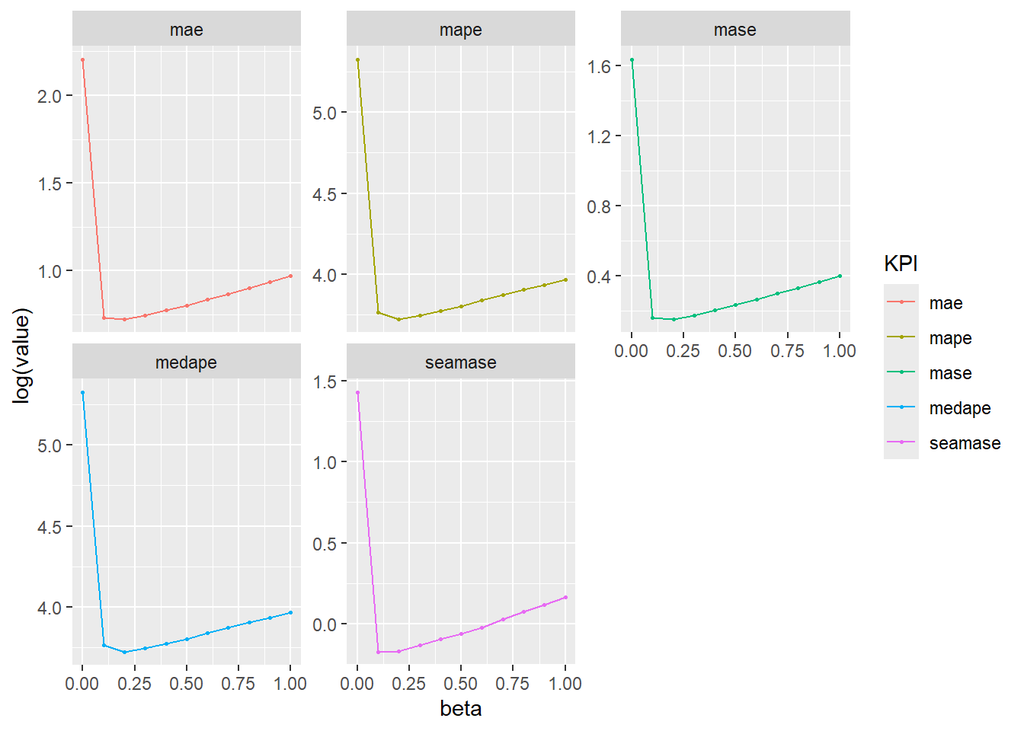

```r
df_param_ates %>%
  filter(alpha == alf_a3,
         gamma == gam_a3) %>%
  select(beta, mae, mape, medape, wape, mase, seamase) %>%
  pivot_longer(cols      = c(mae, mape, medape, mase, seamase),
               names_to  = "KPI",
               values_to = "value") %>%
  ggplot(aes(x = beta, y = log(value), color = KPI)) +
    geom_point(size = 0.5) +
    geom_line() +
    facet_wrap(~ KPI,
               scale = "free_y")
```

We see that the best beta is indeed $0.2$ for all but the seamase KPIs, but it is not very far from $0.1$. We will keep $0.2$. Let’s check the same for the multiplicative model:

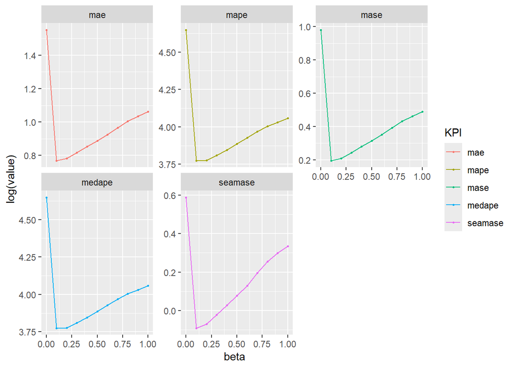

```r
df_param_mtes %>%
  filter(alpha == alf_m3,
         gamma == gam_a3) %>%
  select(beta, mae, mape, medape, wape, mase, seamase) %>%
  pivot_longer(cols      = c(mae, mape, medape, mase, seamase),
               names_to  = "KPI",
               values_to = "value") %>%
  ggplot(aes(x = beta, y = log(value), color = KPI)) +
    geom_point(size = 0.5) +
    geom_line() +
    facet_wrap(~ KPI,
               scale = "free_y")
```

Here it makes sense to keep $\beta =$ 0.1.

**Important 1: To do at home**

We saw that for DES, the initial value $b(0) = 0$ gave better results. Re-do the same analysis using $b(0) = 0$ instead of $b(0) = d(1) - d(0)$.

Let’s compute the accuracy KPIs for additive TES using $b(0) = 0$:

```r
df_param_ates_b0 <- fun_kpi_tes(df_ts3, fun_tes_add, aa_1, 0, sa_1)
```

```
alpha = 0
Alpha iteration 1: 9.75 seconds
alpha = 0.1
Alpha iteration 2: 9.82 seconds
alpha = 0.2
Alpha iteration 3: 9.61 seconds
alpha = 0.3
Alpha iteration 4: 8.92 seconds
alpha = 0.4
Alpha iteration 5: 8.78 seconds
alpha = 0.5
Alpha iteration 6: 9.1 seconds
alpha = 0.6
Alpha iteration 7: 8.86 seconds
alpha = 0.7
Alpha iteration 8: 9.03 seconds
alpha = 0.8
Alpha iteration 9: 10.45 seconds
alpha = 0.9
Alpha iteration 10: 13.89 seconds
alpha = 1
Alpha iteration 11: 14.18 seconds
Time to optimize params through 11x11x11x1 grid search: 1.87 minutes
```

```r
df_param_ates_b0
```

```
# A tibble: 1,331 × 17
   alpha  beta gamma   phi horizon   mae mae_d  mape mape_d medape medape_d
   <dbl> <dbl> <dbl> <dbl>   <dbl> <dbl> <dbl> <dbl>  <dbl>  <dbl>    <dbl>
 1     0     0   0       1       1  3.94  1.26  69.4   25.2   69.4     25.2
 2     0     0   0.1     1       1  3.80  1.26  66.8   25.2   66.8     25.2
 3     0     0   0.2     1       1  3.66  1.26  64.2   25.2   64.2     25.2
 4     0     0   0.3     1       1  3.53  1.26  61.8   25.2   61.8     25.2
 5     0     0   0.4     1       1  3.41  1.26  59.7   25.2   59.7     25.2
 6     0     0   0.5     1       1  3.31  1.26  58.1   25.2   58.1     25.2
 7     0     0   0.6     1       1  3.22  1.26  56.9   25.2   56.9     25.2
 8     0     0   0.7     1       1  3.16  1.26  56.1   25.2   56.1     25.2
 9     0     0   0.8     1       1  3.12  1.26  55.8   25.2   55.8     25.2
10     0     0   0.9     1       1  3.10  1.26  56.0   25.2   56.0     25.2
# ℹ 1,321 more rows
# ℹ 6 more variables: wape <dbl>, wape_d <dbl>, mase <dbl>, mase_d <dbl>,
#   seamase <dbl>, seamase_d <dbl>
```

And for multiplicative TES using $b(0) = 0$:

```r
df_param_mtes_b0 <- fun_kpi_tes(df_ts3, fun_tes_mult, am_1, 0, sm_1)
```

```
alpha = 0
Alpha iteration 1: 13.81 seconds
alpha = 0.1
Alpha iteration 2: 14.41 seconds
alpha = 0.2
Alpha iteration 3: 14.09 seconds
alpha = 0.3
Alpha iteration 4: 14.16 seconds
alpha = 0.4
Alpha iteration 5: 14.25 seconds
alpha = 0.5
Alpha iteration 6: 13.91 seconds
alpha = 0.6
Alpha iteration 7: 13.56 seconds
alpha = 0.7
Alpha iteration 8: 14.14 seconds
alpha = 0.8
Alpha iteration 9: 13.97 seconds
alpha = 0.9
Alpha iteration 10: 14.05 seconds
alpha = 1
Alpha iteration 11: 14.17 seconds
Time to optimize params through 11x11x11x1 grid search: 2.58 minutes
```

```r
df_param_mtes_b0
```

```
# A tibble: 1,331 × 17
   alpha  beta gamma   phi horizon   mae mae_d  mape mape_d medape medape_d
   <dbl> <dbl> <dbl> <dbl>   <dbl> <dbl> <dbl> <dbl>  <dbl>  <dbl>    <dbl>
 1     0     0   0       1       1  3.37  1.26  53.7   25.2   53.7     25.2
 2     0     0   0.1     1       1  3.25  1.26  51.6   25.2   51.6     25.2
 3     0     0   0.2     1       1  3.13  1.26  49.6   25.2   49.6     25.2
 4     0     0   0.3     1       1  3.03  1.26  48.0   25.2   48.0     25.2
 5     0     0   0.4     1       1  2.94  1.26  46.6   25.2   46.6     25.2
 6     0     0   0.5     1       1  2.87  1.26  45.7   25.2   45.7     25.2
 7     0     0   0.6     1       1  2.82  1.26  45.3   25.2   45.3     25.2
 8     0     0   0.7     1       1  2.79  1.26  45.2   25.2   45.2     25.2
 9     0     0   0.8     1       1  2.77  1.26  45.5   25.2   45.5     25.2
10     0     0   0.9     1       1  2.78  1.26  46.0   25.2   46.0     25.2
# ℹ 1,321 more rows
# ℹ 6 more variables: wape <dbl>, wape_d <dbl>, mase <dbl>, mase_d <dbl>,
#   seamase <dbl>, seamase_d <dbl>
```

Let’s find the parameters for the minimum KPIs:

```r
df_param_ates_b0_min <-
  df_param_ates_b0 %>%
  filter(mae     == min(mae)    |
         mape    == min(mape)   |
         medape  == min(medape) |
         wape    == min(wape)   |
         mase    == min(mase)   |
         seamase == min(seamase)) %>%
  arrange(desc(wape))
df_param_ates_b0_min
```

```
# A tibble: 2 × 17
  alpha  beta gamma   phi horizon   mae mae_d  mape mape_d medape medape_d  wape
  <dbl> <dbl> <dbl> <dbl>   <dbl> <dbl> <dbl> <dbl>  <dbl>  <dbl>    <dbl> <dbl>
1   0.3     0   0.6     1       1  1.93  1.26  39.1   25.2   39.1     25.2  33.5
2   0.3     0   0.7     1       1  1.93  1.26  39.1   25.2   39.1     25.2  33.5
# ℹ 5 more variables: wape_d <dbl>, mase <dbl>, mase_d <dbl>, seamase <dbl>,
#   seamase_d <dbl>
```

```r
df_param_mtes_b0_min <-
  df_param_mtes_b0 %>%
  filter(mae     == min(mae)    |
         mape    == min(mape)   |
         medape  == min(medape) |
         wape    == min(wape)   |
         mase    == min(mase)   |
         seamase == min(seamase)) %>%
  arrange(desc(wape))
df_param_mtes_b0_min
```

```
# A tibble: 2 × 17
  alpha  beta gamma   phi horizon   mae mae_d  mape mape_d medape medape_d  wape
  <dbl> <dbl> <dbl> <dbl>   <dbl> <dbl> <dbl> <dbl>  <dbl>  <dbl>    <dbl> <dbl>
1   0.3   0.1   0.6     1       1  2.13  1.26  42.6   25.2   42.6     25.2  36.9
2   0.3   0     0.7     1       1  2.08  1.26  43.0   25.2   43.0     25.2  36.1
# ℹ 5 more variables: wape_d <dbl>, mase <dbl>, mase_d <dbl>, seamase <dbl>,
#   seamase_d <dbl>
```

```r
min_wape_add_b0  <- df_param_ates_b0_min$wape %>% last
min_wape_mult_b0 <- df_param_mtes_b0_min$wape %>% last

alf_a4 <- df_param_ates_b0_min$alpha %>% last %>% round(digits = 1)
bet_a4 <- df_param_ates_b0_min$beta  %>% last %>% round(digits = 1)
gam_a4 <- df_param_ates_b0_min$gamma %>% last %>% round(digits = 1)
alf_m4 <- df_param_mtes_b0_min$alpha %>% last %>% round(digits = 1)
bet_m4 <- df_param_mtes_b0_min$beta  %>% last %>% round(digits = 1)
gam_m4 <- df_param_mtes_b0_min$gamma %>% last %>% round(digits = 1)

best_albega_a4 <- c(alf_a4, bet_a4, gam_a4)
best_albega_a4
```

```
[1] 0.3 0.0 0.7
```

```r
best_albega_m4 <- c(alf_m4, bet_m4, gam_m4)
best_albega_m4
```

```
[1] 0.3 0.0 0.7
```

**Important 2: To do at home**

Replicate the analysis for $\phi$ for TES that we did for DES in section Section 2.1.6 .

Let’s re-run our grid search with phi ranging over $(0.5, 0.8, 1)$ and for horizon 7 days.

```r
df_param_addes_3 <- fun_kpi_tes(df_ts3, fun_tes_add, aa_1, ba_1, sa_1, seq_fi = c(0.5, 0.8, 1), hoz_00 = 7)
```

```
alpha = 0
Alpha iteration 1: 43.24 seconds
alpha = 0.1
Alpha iteration 2: 42.62 seconds
alpha = 0.2
Alpha iteration 3: 42.85 seconds
alpha = 0.3
Alpha iteration 4: 42.84 seconds
alpha = 0.4
Alpha iteration 5: 43.36 seconds
alpha = 0.5
Alpha iteration 6: 42.43 seconds
alpha = 0.6
Alpha iteration 7: 42.79 seconds
alpha = 0.7
Alpha iteration 8: 43.13 seconds
alpha = 0.8
Alpha iteration 9: 42.5 seconds
alpha = 0.9
Alpha iteration 10: 43.04 seconds
alpha = 1
Alpha iteration 11: 42.77 seconds
Time to optimize params through 11x11x11x3 grid search: 7.86 minutes
```

```r
df_param_addes_3
```

```
# A tibble: 3,993 × 17
   alpha  beta gamma   phi horizon    mae mae_d    mape mape_d  medape medape_d
   <dbl> <dbl> <dbl> <dbl>   <dbl>  <dbl> <dbl>   <dbl>  <dbl>   <dbl>    <dbl>
 1     0     0   0     0.5       7   2.77  1.26    50.0   25.2    50.0     25.2
 2     0     0   0     0.8       7   7.72  1.26   180.    25.2   180.      25.2
 3     0     0   0     1         7 896.    1.26 17703.    25.2 17703.      25.2
 4     0     0   0.1   0.5       7   2.72  1.26    49.1   25.2    49.1     25.2
 5     0     0   0.1   0.8       7   7.42  1.26   174.    25.2   174.      25.2
 6     0     0   0.1   1         7 878.    1.26 17375.    25.2 17375.      25.2
 7     0     0   0.2   0.5       7   2.67  1.26    48.4   25.2    48.4     25.2
 8     0     0   0.2   0.8       7   7.13  1.26   167.    25.2   167.      25.2
 9     0     0   0.2   1         7 861.    1.26 17047.    25.2 17047.      25.2
10     0     0   0.3   0.5       7   2.64  1.26    47.9   25.2    47.9     25.2
# ℹ 3,983 more rows
# ℹ 6 more variables: wape <dbl>, wape_d <dbl>, mase <dbl>, mase_d <dbl>,
#   seamase <dbl>, seamase_d <dbl>
```

Let’s check the minimum KPIs:

```r
df_param_addes_3 %>%
  filter(mae     == min(mae)    |
         mape    == min(mape)   |
         medape  == min(medape) |
         wape    == min(wape)   |
         mase    == min(mase)   |
         seamase == min(seamase))
```

```
# A tibble: 2 × 17
  alpha  beta gamma   phi horizon   mae mae_d  mape mape_d medape medape_d  wape
  <dbl> <dbl> <dbl> <dbl>   <dbl> <dbl> <dbl> <dbl>  <dbl>  <dbl>    <dbl> <dbl>
1   0.2   0.5   0.5   0.5       7  2.15  1.26  42.5   25.2   42.5     25.2  37.3
2   0.2   0.8   0.5   0.5       7  2.15  1.26  42.4   25.2   42.4     25.2  37.2
# ℹ 5 more variables: wape_d <dbl>, mase <dbl>, mase_d <dbl>, seamase <dbl>,
#   seamase_d <dbl>
```

```r
alf_a3 <- 0.3
bet_a3 <- 0.0
gam_a3 <- 0.7
```

Let’s pick $\alpha = 0.3$, $\beta = 0$, and $\gamma = 0.7$ and check the KPIs for the different values of phi:

```r
df_param_addes_3 %>%
  filter(alpha == alf_a3,
         beta  == bet_a3,
         gamma  == gam_a3) %>%
  select(-matches("_d$"))
```

```
# A tibble: 3 × 11
  alpha  beta gamma   phi horizon   mae  mape medape  wape  mase seamase
  <dbl> <dbl> <dbl> <dbl>   <dbl> <dbl> <dbl>  <dbl> <dbl> <dbl>   <dbl>
1   0.3     0   0.7   0.5       7  2.16  42.8   42.8  37.5  1.22   0.875
2   0.3     0   0.7   0.8       7  2.23  44.6   44.6  38.7  1.26   0.884
3   0.3     0   0.7   1         7 25.4  559.   559.  441.  14.4   11.7
```

**Important 3: To do at home**

What arguments should you set to what in fun_tes_add to make it into a fun_des_add?

# Optimization by builtin optimizers

Grid search is very useful to visualize how the KPIs change with the parameters, and for a 11x11x11 grid, it is not very expensive. This is one of the main advantage of Holt-Winters (TES) forecasting: It is very frugal in terms of parameters (only 3, or 4 counting damping), and does very well with that (compared with ARIMA for example).

But the time needed to compute the best parameters also depends on the size and numbers of the datasets. If we have hundreds of daily TS, over 5 or more years, it might prove timely impractical. So, in these cases we need to use more efficient optimizers, and there are plenty in R or python. Here we will use only the base “optim()” one in R:

We need to pass the optimizer a cost function. Here we will use the WAPE function, but the function for other KPIs can be used in parallel.

```r
fun_cost_wape <- function(abc, #for more than 1 parameter, input a vector.
                         a_00, b_00, s_00,
                         fun_tes, df_00 = df_ts3) {
  alf_00 <- abc[1]
  bet_00 <- abc[2]
  gam_00 <- abc[3]
  n_dat  <- nrow(df_00)
  df_00 <-
    fun_tes(df_0  = df_00,
            a_0   = a_00,
            b_0   = b_00,
            s_0   = s_00,
            alf_0 = alf_00,
            bet_0 = bet_00,
            gam_0 = gam_00,
            fi_0  = 1)
  return(fun_wape(df_00$fcast_tes, df_00$d_t))
}

print(fun_cost_wape)
```

```
function (abc, a_00, b_00, s_00, fun_tes, df_00 = df_ts3)
{
    alf_00 <- abc[1]
    bet_00 <- abc[2]
    gam_00 <- abc[3]
    n_dat <- nrow(df_00)
    df_00 <- fun_tes(df_0 = df_00, a_0 = a_00, b_0 = b_00, s_0 = s_00,
        alf_0 = alf_00, bet_0 = bet_00, gam_0 = gam_00, fi_0 = 1)
    return(fun_wape(df_00$fcast_tes, df_00$d_t))
}
```

```r
init_albega_1 <- c(0.5, 0.5, 0.5)
```

We also need to pass it some initial values for the parameters to optimize on. Here we’ll uses $abc = (a(0), b(0), c(0)) =$ 0.5, 0.5, 0.5.

We can now run the optimizer (for additive and multiplicative models):

```r
oo_add_1 <-
  optim(par = init_albega_1,
        fn = fun_cost_wape,
        a_00 = aa_1, b_00 = ba_1, s_00 = sa_1,
        fun_tes = fun_tes_add, df_00 = df_ts3)

oo_mult_1 <-
  optim(par = init_albega_1,
        fn = fun_cost_wape,
        a_00 = aa_1, b_00 = ba_1, s_00 = sm_1,
        fun_tes = fun_tes_mult, df_00 = df_ts3)
```

## Additive model

Let’s see the parameters found and the minimized WAPE value:

```r
tibble(method       = rep(c("grid_search", "optimizer"), each = 2),
       result_type  = rep(c("alpha__beta__gamma", "min_WAPE"), 2),
       result_value = list(c(best_albega_a3), min_wape_add, oo_add_1$par, oo_add_1$value) %>% map(round, digits = 2) %>% map_chr(paste, collapse = "__"))
```

```
# A tibble: 4 × 3
  method      result_type        result_value
  <chr>       <chr>              <chr>
1 grid_search alpha__beta__gamma 0.3__0.2__0.5
2 grid_search min_WAPE           35.72
3 optimizer   alpha__beta__gamma 0.31__0.17__0.52
4 optimizer   min_WAPE           35.89
```

We see that the parameters found are close to the ones we found by grid search (0.3, 0.2, 0.5).

The minimum WAPE is a little larger than the one grid search found (35.7179841).

## Multiplicative model

```r
tibble(method       = rep(c("grid_search", "optimizer"), each = 2),
       result_type  = rep(c("alpha__beta__gamma", "min_WAPE"), 2),
       result_value = list(c(best_albega_m3), min_wape_mult, oo_mult_1$par, oo_mult_1$value) %>% map(round, digits = 2) %>% map_chr(paste, collapse = "__"))
```

```
# A tibble: 4 × 3
  method      result_type        result_value
  <chr>       <chr>              <chr>
1 grid_search alpha__beta__gamma 0.3__0.1__0.6
2 grid_search min_WAPE           37.36
3 optimizer   alpha__beta__gamma 0.3__0.12__0.54
4 optimizer   min_WAPE           38.09
```

```r
init_albega_2 <- c(0, 0, 0)
init_albega_3 <- c(1, 1, 1)
```

Similarly for the multiplicative model

Sometimes the optimizer results (local minima) are very dependent on the initial values.

**Important 4: To do at home**

For our optimizer we took “middle” values (0.5) as initial values for $\alpha, \beta, \gamma$. Do you get the same results from “extreme” initial values (0, 0, 0) and (1, 1, 1)?